# How do regional factors influence the prescribing rate of Naproxen by GP practices?

2025-10-31

## 1. Introduction

Scotland’s demographic trend show an increase in the population of older adults (www.gov.scot, n.d.). I chose this topic because age is one of the strongest predictors of chronic pain and inflammatory disorders(Booker et al., 2020). Non-steroidal anti-inflammatory drugs (NSAIDs), such as Naproxen is used in primary care for a range of acute and chronic inflammatory conditions that are often associated with age(NHS, 2022). Understanding how demographic structures shape the demand for such medications is essential for effective health service planning and equitable resource allocation. I chose to focus on Naproxen (500mg) as it is the second most used NSAID in Scotland (NHS website, 2017). This report examines prescribing patterns of Naproxen (500mg) across Scottish Health boards between in December 2016,2020 and 2024. December was the month I focused on due to evidence suggesting a seasonal rise in inflammatory responses during the winter(Roberts, 2015).

**Hypothesis:** Health boards with a higher proportion of older adults will show higher rates Naproxen prescriptions.

## 2. Data & Methods

**Prescribing data:** Public Health Scotland, [Prescriptions in the Community](https://www.opendata.nhs.scot/dataset/prescriptions-in-the-community) . Downloaded “Data by Prescriber Location” files from December 2016, 2020 and 2024. This can be found in the hyperlink above.

**Geographic Data:** Public Health Scotland, [Health Boards](https://www.opendata.nhs.scot/dataset/geography-codes-and-labels/resource/652ff726-e676-4a20-abda-435b98dd7bdc) For the names of the Health Boards. data.gov.uk [NHS Health Boards (zip file)](https://www.data.gov.uk/dataset/27d0fe5f-79bb-4116-aec9-a8e565ff756a/nhs-health-boards-scotland) For geometry.

**Population Estimate:** [Health Board Projections](https://www.opendata.nhs.scot/dataset/population-projections/resource/0876fc67-05e6-4e87-bc30-c4b0756fff04) For the estimate of age population.

#### 2.1 Loading packages

```r
#Required R packages: tidyverse, janitor, gt, here, dplyr, sf, ggplot2, kableExtra.
library(tidyverse)
library(janitor)
library(gt)
library(here)
library(dplyr)
library(sf)
library(ggplot2)
library(kableExtra)
```

## 3. Analysis of Naproxen Prescribing Overtime

To initiate the analysis, my first step is to identify the health board with the highest volume of Naproxen prescriptions across the observed longitudinal period. This will provide a basis I can use to look closely at its population in 2024.

```r
#reading CSV files
data_dec2020 <- read_csv(here("data", "Data_by_Prescriber_Location_December_2020.csv")) %>%
  clean_names() %>%
   mutate(year = 2020) %>% #Adding new column
  select(bnf_item_description, paid_quantity, hbt, year) #selecting relevant columns

data_dec2024 <- read_csv(here("data", "Data_by_Prescriber_Location_December_2024.csv")) %>%
  clean_names() %>%
   mutate(year = 2024) %>%
   select(bnf_item_description, paid_quantity, hbt, year)


data_dec2016 <- read_csv(here("data", "Data_by_Prescriber_Location_December_2016.csv")) %>%
  clean_names() %>%
   mutate(year = 2016) %>%
    rename(hbt = hbt2014) %>%
select(bnf_item_description, paid_quantity, hbt, year)


hbt_names <- read_csv(here("data", "hb14_hb19.csv")) %>%
  clean_names()

#Joining dataframes into a single one
combined_dec <- bind_rows(data_dec2020, data_dec2024, data_dec2016) #join for single df
```

```r
#Join for HB names
joined_df <- combined_dec %>%
  left_join(hbt_names, by = c("hbt" = "hb")) %>%
  select(bnf_item_description, paid_quantity, hbt, hb_name, year)
```

```r
#Needed for Map and Graph but placed here for the sake of knitting
data_age2024 <- read_csv(here("data", "Health_Board_Projections.csv")) %>%
clean_names() %>%
  select(year, hb, age50:age90plus)

joined_age_df <- data_age2024 %>%
  filter(year == 2024) %>%
  left_join(hbt_names, by = "hb") %>%
    # Remove any rows where the health board name is missing
  filter(!is.na(hb_name)) %>%
  mutate(total_population = rowSums(across(starts_with("age")), na.rm = TRUE)) %>%
  mutate(pop_65plus = rowSums(across(age65:age90plus), na.rm = TRUE)) %>%
  group_by(hb_name) %>%
  # Sum total population and 65+ population for each health board
  summarise(
    total_population = sum(total_population, na.rm = TRUE),
    pop_65plus = sum(pop_65plus, na.rm = TRUE)
  ) %>%
  select(hb_name, total_population, pop_65plus)
```

```r
#Filter for NAPROXEN
joined_df_nap <- joined_df %>%
  filter(str_detect(tolower(bnf_item_description), "naproxen")) %>%   # Keep only rows where the drug name contains "naproxen"
  filter(str_detect(bnf_item_description, "500")) %>%
    filter(!is.na(hb_name)) %>%  # Remove any rows where the health board name is missing
  group_by(hb_name, year) %>%
  summarise(total_paid_quantity = sum(paid_quantity), .groups = "drop") %>%
  arrange(hb_name, year) %>%
  left_join(joined_age_df, by = "hb_name") %>%
  mutate(rate_per_1000 = (total_paid_quantity / total_population) * 1000)   # Calculate Naproxen prescriptions per 1,000 people
```

#### 3.1. Figure 1. REGIONAL ANALYSIS OF NAPROXEN

Below is a faceted bar graph illustrating the total paid quantity of Naproxen 500mg prescribed across NHS Scotland Health Boards for the year 2016, 2020 and 2024.

[figure not shown]

```r
#Plot for prescribing rate of Naproxen Across health boards
ggplot(joined_df_nap, aes(x = total_paid_quantity, y = factor(year), fill = factor(year))) +
  geom_col(width = 0.7, show.legend = FALSE) +
  facet_wrap(~ hb_name, scales = "free_y", ncol = 4) +
  #adding lables
  labs(
    x = "Prescribing Rate per 1,000 Population",
    y = "Year" ,
    title = "Naproxen 500mg Prescribing per 1,000 Population Across Health Boards (2016–2024)"
  ) +
   scale_fill_brewer(palette = "PuRd") + # Use a colour palette from RColorBrewer (purple-red gradient)
  theme_minimal(base_size = 12) +
  theme(
    strip.text = element_text(size = 7, face = "bold"),
    axis.text.x = element_text(angle = 45, hjust = 1),
    plot.title = element_text(size = 10, face = "bold", hjust = 0.8),
    panel.spacing = unit(1, "lines")
  )
```

## 4. Age Related Variation in Naproxen Prescribing (2024)

Now to explore the proportion of individuals aged 65 and over within Scotland. I did this to see if I can identify a correlation between age and Naproxen prescriptions.

```r
#Load Data for Map
 hbt_names <- read_csv(here("data", "hb14_hb19.csv")) %>%
  clean_names()

scot_census2019 <- read_sf(here("C:/Users/user/OneDrive - University of Edinburgh/data-science/B249236/data","Week6_NHS_healthboards_2019.shp")) %>%
  clean_names()
```

```r
age65plus <- joined_age_df %>%
  mutate(hb_name = gsub("^NHS\\s+", "", hb_name)) %>%  # remove NHS
  mutate(hb_name = stringr::str_to_title(hb_name)) %>% # convert to Title Case
  mutate(rate_65plus = (pop_65plus / total_population) * 1000)
```

#### 4.1. Figure 2. GEOGRAPHIC DISTRIBUTION

Below is a choropleth map of Scotland that displays the proportion of adults aged 65 and over per 1,000 people.

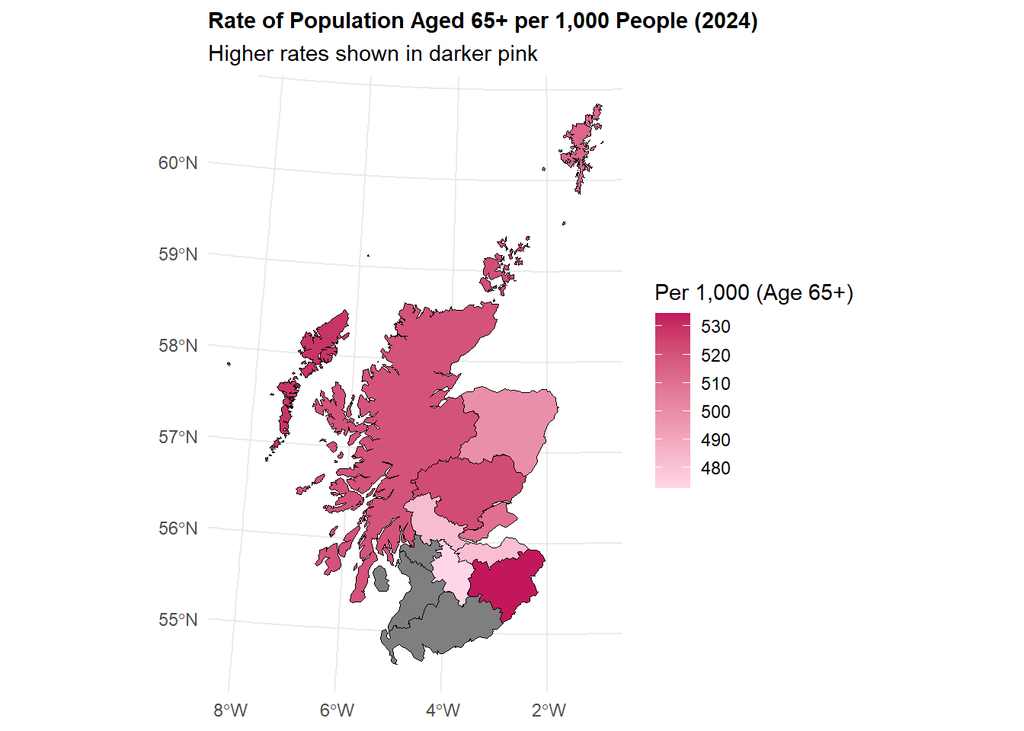

```r
map_df <- scot_census2019 %>%
  left_join(age65plus, by = "hb_name")

ggplot(map_df) +
  geom_sf(aes(fill = rate_65plus), colour = "black", size = 0.3) +
  scale_fill_gradient(
    low = "#FFD6E8",
    high = "#C2185B",
    name = "Per 1,000 (Age 65+)"
  ) +
  labs(
    title = "Rate of Population Aged 65+ per 1,000 People (2024)",
    subtitle = "Higher rates shown in darker pink"
  ) +
  theme_minimal() +
  theme(
    legend.position = "right",
    plot.title = element_text(face = "bold", size = 11)
  )
```

## 5 Population Influences

After this, I went to look at how population might influence the prescription rate of Naproxen, and tshis was displayed in a table i created in figue 3

#### 5.1 Figure 3. TABLE OF POPULATION

```r
#table
age65plus %>%
  arrange(desc(rate_65plus)) %>%   #sort highest to lowest
  kbl(
    caption = "Population Aged 65+ and Rate per 1,000 Population by Health Board (2024)",
    digits = 1,
    col.names = c("Health Board", "Total Population", "Population 65+", "Rate per 1,000")
  ) %>%
  kable_classic(full_width = FALSE, html_font = "Arial") %>%
  column_spec(1, bold = TRUE) %>%  # bold health board names
  column_spec(4, color = "white", background = "#C2185B") %>%  # highlight rate column
  row_spec(0, bold = TRUE, background = "#FFD6E8")             # header styling
```

Population Aged 65+ and Rate per 1,000 Population by Health Board (2024)

| Health Board | Total Population | Population 65+ | Rate per 1,000 |
| --- | --- | --- | --- |
| Dumfries And Galloway | 151454 | 82032 | 541.6 |
| Borders | 120720 | 64534 | 534.6 |
| Western Isles | 27128 | 14348 | 528.9 |
| Tayside | 369320 | 192904 | 522.3 |
| Orkney | 21982 | 11468 | 521.7 |
| Highland | 318784 | 165784 | 520.1 |
| Ayrshire And Arran | 349112 | 181106 | 518.8 |
| Shetland | 20502 | 10522 | 513.2 |
| Fife | 328326 | 167384 | 509.8 |
| Grampian | 485382 | 242264 | 499.1 |
| Forth Valley | 261688 | 126218 | 482.3 |
| Lothian | 678450 | 326624 | 481.4 |
| Greater Glasgow And Clyde | 902330 | 429788 | 476.3 |
| Lanarkshire | 562792 | 266004 | 472.7 |

Although Dumfries and Galloway has the highest proportion of individuals aged 65 and over , Glasgow and Clyde has the biggest population overall. This broader population could explain its higher volume of Naproxen prescriptions. Therefore, interpreting prescription volume without adjusting for population size or demographic structure risks overstating the extent to which age alone explains regional variation.

## 7. Limitations & Future Work

A key limitations is the fact that my analysis focused solely on age and population. However, socioeconomic backgrounds and local morbidity factors may also influence prescription rate. Another limitation I faced is the focus on the month of December.Because December data may not reflect year-round patterns, future research should analyse full-year prescribing to reduce potential selection bias.

## 8. References

Booker, S.Q., Sibille, K.T., Terry, E.L., Cardoso, J.S., Goodin, B.R., Sotolongo, A., Staud, R., Redden, D.T., Bradley, L.A., Fillingim, R.B. and Bartley, E.J. (2020). Psychological Predictors of Perceived Age and Chronic Pain Impact in Individuals with and without Knee Osteoarthritis. The Clinical Journal of Pain, p.1. doi:https://doi.org/10.1097/ajp.0000000000000842.

NHS website (2017). NSAIDs. [online] nhs.uk. Available at: https://www.nhs.uk/medicines/nsaids/.

NHS (2022). About naproxen. [online] nhs.uk. Available at: https://www.nhs.uk/medicines/naproxen/about-naproxen/.

Roberts, M. (2015). Seasons affect ‘how genes and immune system work’. BBC News. [online] 12 May. Available at: https://www.bbc.co.uk/news/health-32687313.

www.gov.scot. (n.d.). Demographic Change in Scotland - gov.scot. [online] Available at: https://www.gov.scot/publications/demographic-change-scotland/pages/4/.